# Digital Clinic Handout

This document presents the data that was collected during your time in the mindLAMP Study. Feel free to reach out to the study team (digitalclinic@cuanschutz.edu) with any questions.

Participant: MIND006  
Age: 90  
Gender: Woman  
Race: White  
**Start Date: 2024-11-09**

# Acitivity and Data Quality

Each week we will provide you with an estimate as to the quality of data we are receiving from the app. The higher the data quality, the better we'll be able to tell you about your day to day activities.

[interactive chart not shown]

The graph below shows all the activities that you completed within the app each day. Dates are along the x-axis, while the y-axis shows how many activities you completed that day. The colors on the bars designate the activity names.

```
Pulling data from LAMP server for all participants...
Finished pulling data. Generating graphs...
U1918167344 data:
```

[interactive chart not shown]

```
Graphs generated. Attaching Graphs...
Analysis complete
```

```
[====================] 100%
```

# Daily Survey Scores and Smartphone Data

The below graphs display different data features collected from your smartphone with your scores on your daily surveys measuring anxiety, function, and mood. The scale for the passive data features is on the left y-axis, and the scale for the daily surveys is on the right y-axis side. The goal of these graphs is to help display patterns between your passive data features and routines with your mood, anxiety, and function levels.

For example, you may see that for days on which you were on your phone screen more, your mood was typically higher.

- Higher anxiety levels correspond with increased anxiety; 0 being no anxiety and 10 being the worst. Higher mood levels correspond with a better mood; 1 being the worst and 10 being the best. Higher function levels correspond with feeling like you are more able to manage day-to-day life on a scale of 0 to 4.
- Entropy is a measure of how much a participant moves around to different locations. Higher entropy typically means that the participant's time is more evenly split between different locations, while low entropy means that a person spends the vast majority of their time at one location.
- Nearby devices is a measure of, if your phone is turned on and connected to bluetooth, how many devices around you are also turned on and connected to bluetooth. It can be used as a measure of sociability. For example, if you are spending a lot of time in spaces with lots of people, like a concert or a busy coffee shop, there will be more people and devices around you.
- Steps are the number of steps you have taken each day, measured using your phone's accelerometer or health app.

[interactive chart not shown]

```
Fewer than 2 Daily Functioning surveys found
```

# Relationships between daily activity and well-being

Below, you'll find a graphic called a correlation matrix which shows how your activity relates to your well-being.

Each box in the chart has a number that tells you if two things increase together (positive numbers, more dark blue), decrease together (negative numbers, lighter yellow green), or don't affect each other (zero). Numbers close to 1 or -1 mean a strong relationship and numbers closer to 0 mean no relationship.

How would you use this information? Maybe you see a negative -0.85 correlation between difficulty functioning and sleep. A negative correlation tells you on days when your sleep is lower, your difficulty functioning tends to be higher.

Questions to think about: How does going on a walk make you feel? Do you usually feel better, worse, or about the same after you go on walks?

[interactive chart not shown]

# Calendar View

These calendars show heatmaps of all of your passive and active variables collected over your time in the clinic. The month is listed on the bottom, the day of the week is shown on the right, and there is a heat map scale on the far right showing the minimum and maximum values for each variable with the corresponding colors.

The goal of these graphs is to help pick up on patterns in passive or active data over time, as well as to pick out what days may have been unusual in terms of passive or active data values.

### Entropy

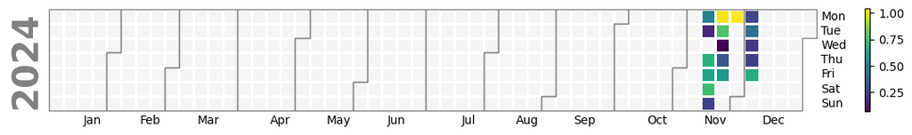

### Hometime

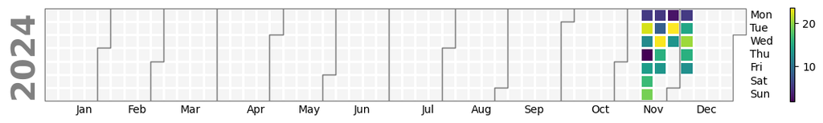

### Data Quality

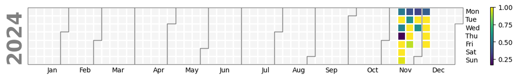

### Screen Duration

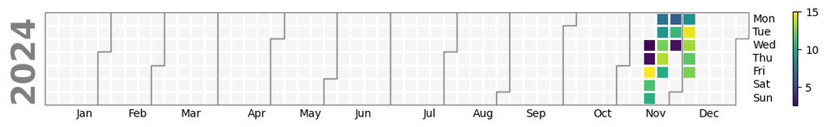

### Steps

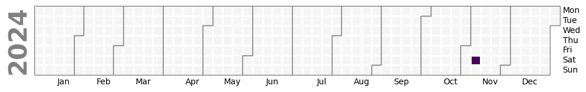

### Anxiety

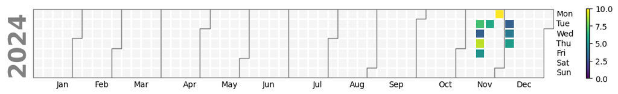

### Depression

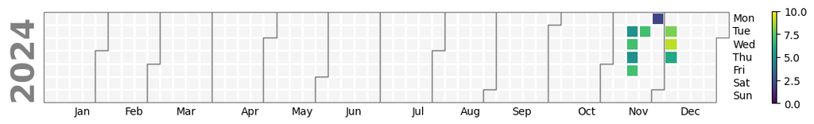

### Difficulty Functioning

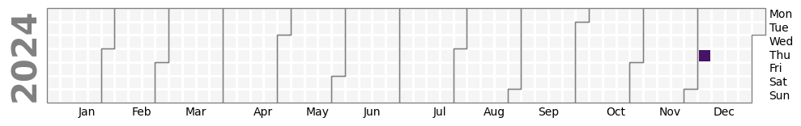

### Sleep Duration

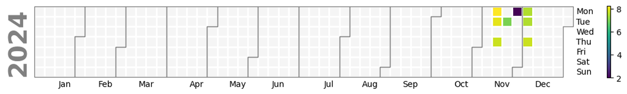

# Your Progress Over Time

Throughout your time in the study, you will complete three surveys: an Intake survey during your first session with your Digital Navigator, an Interim survey after your third meeting with your clinician, and a Completion survey at the end of your last appointment.

The graph below displays your responses to survey questions measuring anxiety, depression, and dysfunction (dysfunction represents how difficult it is to manage your day-to-day life and responsibilities). You can toggle over the survey category on the right to view all your survey responses together, or to only view your results from one of the surveys (just the Intake, for example). Clicking on the points on the graph shows your numerical score and what it is out of. Higher scores indicate having more symptoms of depression, anxiety, and/or dysfunction.

We hope this graph will help you see what areas you have made progress in during your time in the study.

[interactive chart not shown]

The graph below displays your responses to survey questions measuring your self efficacy, motivation, digital literacy, emotional self awareness, and perceived social support. Like in the first graph, you can toggle over which survey you are seeing on the right, or you can click on the graph points to look at your numerical scores. Higher scores indicate greater feelings of motivation, self efficacy, self awareness, and social support, or a greater amount of digital literacy.

The goal of this graph it so show what areas you have grown in during your time in the Digital Clinic.

[interactive chart not shown]

# Weekly Surveys

During your time in the clinic, you completed weekly surveys measuring anxiety (GAD-7), depression (PHQ-9) levels, and sleep quality. The line graph shows your scores over your time in the clinic, with blue measuring anxiety, red measuring depression levels, and green measuring sleep quality. The goal of this graph is to measure your progress with your depression and anxiety symptoms throughout your time in the clinic.

Higher scores designate higher values of depression and anxiety. Anxiety values are measured from 0 to 21, and depression values are measured from 0 to 27. Your sleep score ranges from 8 to 40, with a 40 representing poor sleep and an 8 representing good sleep. The lower the score, the better your sleep quality.

[interactive chart not shown]

[output not shown]